# Extensions

This the companion notebook for the session on **extensions** of machine learning tools for factor investing.

The extensions go in four very different directions:

- a short implementation of **SVM**s, a new (in this course) tool for regression or classification
- one example of **model ensemble** in which the combination of models is determined by the covariance of their errors
- two examples of **local interpretability**, namely **LIME** and **Shapley values**
- finally, we discuss a test for Sharpe ratios of batches of strategies

$\rightarrow$ **ABOUT THE NOTEBOOK**:

- the code chunks are **sequential**. They must be executed in the correct order.
- text between **stars** appears in bold in html format.

# 1 Support vector machines

We start by loading the data and the required **packages**. For SVMs, **e1071** is a good choice as it is built on the well-known **libsvm** library.

```r
if(!require(e1071)){install.packages("e1071")} # ML package used for SVM modelling
library(tidyverse)
library(e1071)
load("data.RData")                                      # Load data
data <- data  %>%
    group_by(Tick) %>%                                  # Returns are computed asset-by-asset
    mutate(F_Return = lead(Close) / Close - 1) %>%      # Adding forward/future returns
    ungroup() %>%                                       # Ungroup
    na.omit()                                           # Remove missing data
```

Below, we also prepare the **raw input**s. We start with the **normalisation of features** and with the **train/test** split. For simplicity, we work with a suboptimal dependent variable, namely simple future returns.

```r
normalise <-  function(v){  # This is a function that 'uniformalises' a vector
    v <- v %>% as.matrix()
    return(ecdf(v)(v))
}
data_f <- data %>%                                       # Data with normalised values
    group_by(Date) %>%                                   # Normalisation takes place for each date
    mutate_at(vars(Mkt_Cap:Prof_Marg), normalise) %>%    # Apply normalisation on features
    ungroup()                                            # Ungroup
sep_date <- as.Date("2010-01-01")                        # Separates in-sample vs out-of-sample
t_oos <- data$Date[data$Date > sep_date] %>%             # Out-of-sample dates (i.e., testing set)
    unique() %>%                                         # Remove duplicates
    as.Date(origin = "1970-01-01")                       # Put in date format
features <- c("Mkt_Cap", "P2B", "Vol_1M", "RSI_1M", "D2E", "Prof_Marg")  # Predictors
train_sample <- data_f %>% filter(Date <= sep_date)      # Train sample
train_features <- select(train_sample, features)         # Train features
test_sample <- data_f %>% filter(Date > sep_date)        # Test sample
test_features <- select(test_sample, features)           # Train features
```

We directly move to the implementation of a SVM-based model. We recall that there are two important options (among others): the **kernel** that is applied upfront to the inputs and the **regularisation intensity**, C (for cost), which is a scaling factor for the sum of slack errors in the objective function.

- For the kernel, the package offers options: **linear**, **radial**, **polynomial** and **sigmoid**.
- The package also offers options with respect to the task: **C-classification**, **nu-classification**, **eps-regression** and **nu-regression**. We refer to the LIBSVM documentation for more details on the differences between these approaches (https://www.csie.ntu.edu.tw/~cjlin/papers/libsvm.pdf).

```r
fit <- svm(y = train_sample$F_Return, # Train features
           x = train_features,        # Train label
           type = "nu-regression",    # SVM task type
           kernel = "radial",         # SVM kernel
           gamma = 0.5,               # Constant in the radial kernel
           cost = 1)                  # Slack variable penalisation
pred <- predict(fit, test_features)   # Store predictions
mean(pred * test_sample$F_Return > 0) # Compute hit ratio
```

```
[1] 0.5063973
```

The **hit-ratio** is barely above 0.50, which means that the signal is not of outstanding quality.

# 2 Ensembe learning

In this section, we implement *one* **optimal combination** of ‘independent’ learners. We start by defining the prediction error function in which we stack all models (**random forest**, **boosted trees** and **SVM**). We also add a **weight feature** in the function: it will compute the errors when the output is a (weighted) linear combination of the 3 algorithms.

```r
library(randomForest)
library(xgboost)
pred_multi <- function(train_data, test_data, weights){
    set.seed(42)    # Sets the pseudo-random generator seed to fix the results (for RF)
    features <- c("Mkt_Cap", "P2B", "Vol_1M", "RSI_1M", "D2E", "Prof_Marg") # Hard-coded
    train_features <- train_data %>% select(features) %>% as.matrix()       # Indep. variable
    train_label <- train_data$F_Return                                      # Dependent variable
    test <- test_data %>%                                                   # Test sample
        select(features) %>%
        as.matrix()
    # 1. Random Forest
    fit <- randomForest(y = train_label,        # Label
                        x = train_features,     # Features
                        ntree = 10,             # Number of random trees
                        mtry = 4                # Nb of predictive variables used for each tree
    )
    err_RF <- predict(fit, test) - test_data$F_Return # Return errors
    # 2. Boosted Trees
    train_matrix <- xgb.DMatrix(data = train_features, label = train_label) # XGB format
    fit <- train_matrix %>%
        xgb.train(data = .,                       # Data source (pipe input)
                  eta = 0.5,                      # Learning rate
                  objective = "reg:linear",       # Number of random trees
                  max_depth = 4,                  # Maximum depth of trees
                  nrounds = 10                    # Number of trees used
        )
    xgb_test <- test_data %>%                     # Test sample => XGB format
        select(features) %>%
        as.matrix() %>%
        xgb.DMatrix
    err_XGB <- predict(fit, xgb_test) - test_data$F_Return # Return errors
    # 3. SVM
    fit <- svm(y = train_label,                 # Train label
               x = train_features,              # Train features
               type = "nu-regression",          # SVM task type
               kernel = "radial",               # SVM kernel
               gamma = 0.5,                     # Constant in the radial kernel
               cost = 1)                        # Slack variable penalisation
    err_SVM <- predict(fit, test) - test_data$F_Return                      # Return errors
    err_AGG <- weights[1]*err_RF + weights[2]*err_XGB + weights[3]*err_SVM  # Aggregate error
    return(data.frame(err_RF, err_XGB, err_SVM, err_AGG))                   # Return all errors
}
```

## 2.1 Simple combination

We are now ready to compute the errors across all three methods (+ the linear combination). The error is computed on the **training samples**!

```r
errors <-  pred_multi(train_data = train_sample,
                      test_data = train_sample, # On training data first!
                      weights = rep(1,3)/3)     # Equal weights at first
errors %>% colMeans()                           # Average error
```

```
      err_RF      err_XGB      err_SVM      err_AGG
0.0012144499 0.0005100136 0.0006981415 0.0008075350
```

```r
errors %>% apply(2, sd)                         # Standard deviation of errors
```

```
    err_RF    err_XGB    err_SVM    err_AGG
0.05504272 0.08875008 0.09107339 0.07559377
```

We then move to the ‘**optimal**’ combination. We compute the covariance of errors and then the derived optimal weights.

```r
cor(errors[,1:3])                       # Corr. matrix of errors of first 3 models (singular if 4)
```

```
           err_RF   err_XGB   err_SVM
err_RF  1.0000000 0.8434490 0.8619225
err_XGB 0.8434490 1.0000000 0.9493678
err_SVM 0.8619225 0.9493678 1.0000000
```

```r
Sigma <- cov(errors[,1:3])              # => stored in Sigma (for future use)
w <- rowSums(solve(Sigma))              # Sum or rows inverse covariance matrix of errors
w / sum(w)                              # Optimal weights
```

```
      err_RF      err_XGB      err_SVM
 1.481659735 -0.002437717 -0.479222018
```

The optimal weights are risky because they create an arbitrage: rely heavily on **RF** and ‘short’ the other two. This comes from the high correlation between the models’ errors.

Let’s see how an **EW combination** performs on the testing set.

```r
errors_2 <- pred_multi(train_data = train_sample,
                      test_data = test_sample,
                      weights = rep(1,3)/3)
errors_2 %>% colMeans()                  # Average error
```

```
      err_RF      err_XGB      err_SVM      err_AGG
-0.002071131 -0.005352926 -0.003628767 -0.003684275
```

```r
errors_2 %>% apply(2, sd)                # Standard deviation of errors
```

```
    err_RF    err_XGB    err_SVM    err_AGG
0.07466344 0.06754035 0.06801210 0.06612711
```

In light of the randomness of the first method, each time we rerun the code, new metrics *should* be generated for the first and last column. This does not happen because we fixed the random number generator by **freezing the random seed**. In terms of bias, it is hard to conclude. In terms of variance, the aggregate forecast usually has a very small advantage.

## 2.2 ‘Optimal’ aggregation

Let’s see how the **optimised combination** performs on the testing set.

```r
errors_3 <- pred_multi(train_data = train_sample,
                      test_data = test_sample,
                      weights = w / sum(w))  # Change weights!
errors_3 %>% colMeans()                      # Average error
```

```
      err_RF      err_XGB      err_SVM      err_AGG
-0.002071131 -0.005352926 -0.003628767 -0.001316678
```

```r
errors_3 %>% apply(2, sd)                    # Standard deviation of errors
```

```
    err_RF    err_XGB    err_SVM    err_AGG
0.07466344 0.06754035 0.06801210 0.08582287
```

Because of the negative (hence, risky) weights, the dispersion of errors of the aggregate prediction is far from competitive. This is a well known fact: **diversification** can only work when the underlying building blocks tell different stories. It is not the case here. Working with variations in feature values could help solve this issue.

## 2.3 Stacked ensemble

It is in fact well known that unconstrained optimisations of learners are risky. In 1996, Breiman introduced the notion of **stacked regressions**. He makes the case that enforcing **positivity of weights** (leading to convex combinations) is the right way to go.

More generally, this has led to a family of sophisticated approaches called **stacked ensembles**. One implementation is provided in the ML library h2o: http://docs.h2o.ai/h2o/latest-stable/h2o-docs/data-science/stacked-ensembles.html

Below, we illustrate this idea using the optimisation package **quadprog**. If we write $\mathbf{\Sigma}$ for the covariance matrix of errors, we seek
$$\mathbf{w}^*=\underset{\mathbf{w}}{\text{argmin}} \ \mathbf{w}'\mathbf{\Sigma}\mathbf{w}, \quad \mathbf{1}'\mathbf{w}=1, \quad w_i\ge 0,$$
The constraints will be handled as:

$$\begin{bmatrix}
1 & 1 & 1 \\
1 & 0 & 0\\
0 & 1 & 0 \\
0 & 0 & 1
\end{bmatrix} \mathbf{w} \hspace{9mm} \text{ compared to} \hspace{9mm} \begin{bmatrix} 1 \\ 0 \\ 0 \\ 0 \end{bmatrix},$$

where the first line will be an equality and the last three will be inequalities.

```r
if(!require(quadprog)){install.packages("quadprog")}
library(quadprog)
nb_mods <- nrow(Sigma)
w_stacked <- solve.QP(Dmat = Sigma,
              dvec = rep(0, nb_mods),
              Amat = rbind(rep(1, nb_mods), diag(nb_mods)) %>% t(),
              bvec = c(1,rep(0, nb_mods)),
              meq = 1
              )
w_stacked$solution
```

```
[1]  1.000000e+00  0.000000e+00 -1.500873e-16
```

The opimal combination consists of taking **RF only**!

# 3 Interpretability

## 3.1 Introduction

In attempts to white-box complex machine learning models, one dichotomy stands out:

- **Global models** seek to determine the relative role of features in the construction of the prediction once the model has been trained. This is for instance the case of **variable importance** is tree-based methods.
- **Local models** aim to characterise how the model behaves around **one particular instance** by considering small variations around this instance. The way these variations are handled by the original model allows to simplify it, i.e., approximate it (e.g., in a linear fashion) to determine the sign and magnitude of each relevant feature in the vicinity of the original instance.

Below, we implement the LIME (**L**ocal **I**nterpretable **M**odel-agnostic **E**xplanations from Ribeiro et al. (2016)) algorithm from the eponymous **R** package. We detail the approach below (we omit the subtlety of the interpretable representations in the original paper as it is not relevant in our context).

The original (complex) model is $f$ and it is approximated at instance $x$ by the interpretable model $g$ that belongs to a large class $G$. The vicinity of $x$ is denoted $\pi_x$ and the complexity of $g$ is written $\Omega(g)$. LIME seeks an interpretation of the form
$$\xi(x)=\underset{g \in G}{\text{argmin}} \, \mathcal{L}(f,g,\pi_x)+\Omega(g),$$
where $\mathcal{L}(f,g,\pi_x)$ is the loss function (error/imprecision) induced by $g$ in the vicinity $\pi_x$ of $x$.

The penalisation $\Omega(g)$ is for instance the number of leaves or depth of a tree or the number of predictors in a linear regression.

The vicinity of $x$ is defined by $\pi_x(z)=e^{-D(x,z)^2/\sigma^2},$ where $D$ is some distance measure. **Note**: this function **decreases** when $z$ shifts away from $x$.

The tricky part is the **loss function**. In order to minimise it, **LIME** generates artificial samples close to $x$ and averages/sums the error on the label that the simple representation makes. The formulation is the following:
$$\mathcal{L}(f,g,\pi_x)=\sum_z \pi_x(z)(f(z)-g(z))^2$$
the errors are weighted according to their distance from the initial instance $x$.

## 3.2 LIME in practice

The all-purpose package for machine learning in R is **caret** (see, e.g., http://topepo.github.io/caret/index.html). We have avoided to work with it up to now (we chose to work directly with individual and more narrowly-scoped packages), but LIME works well with **caret**, so it is time to test it! Also note that in fact **caret** resorts to pre-existing packages, like **randomForest** for instance. Finally, a bluit-in tool is included in **caret** for **grid optimisation** on hyperparameters and another one that computes **variable importance**: **caret** does pretty much everything!

```r
if(!require(lime)){install.packages(c("lime", "caret"))}
library(lime)
library(caret)
grid_default <- expand.grid( # Must include ALL XGB PARAMETERS! If not => error.
  nrounds = 10,
  max_depth = 5,
  eta = 0.8,
  gamma = 0.1,
  colsample_bytree = 1,
  min_child_weight = 1,
  subsample = 1
)
fit <- train(y = train_sample$F_Return,       # Train features
             x = as.matrix(train_features),   # Train label
             method = "xgbTree",              # For boosted trees
             tuneGrid = grid_default
  )
explainer <- lime(train_features, fit)   # First step in LIME
```

The list of all models in **caret** can be found here (there are many ~240): https://topepo.github.io/caret/available-models.html

The **LIME** package proceeds in two steps. First, the **lime**() function (used above) embeds the model and the distribution of features. This allows the second step (below) to generate random points around the chosen instance. This second step is performed by the **explain**() function. This function has many options which do not review. We refer to https://uc-r.github.io/lime for a detailed overview.

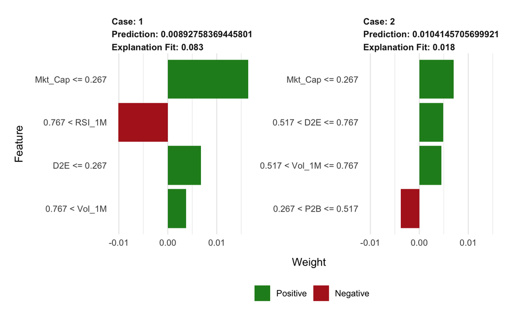

```r
explanation <- explain(
  x = train_features[1:2,],              # We look at the first two instances in train_sample
  explainer = explainer,                 # Input: the explainer variable created above
  n_permutations = 1000,                 # Nb samples used for the loss function
  dist_fun = "gower",                    # Distance function. "euclidean" is one alternative
  n_features = 4
  )
plot_features(explanation)               # Plot!
```

In the arguments of **explain**(), we asked explanations for 2 instances (the first two in train_feature). Moreover, we asked for exactly 4 features. The above graph shows these features for the two instances. A green/red colour highlights a positive/negative effect of the feature and the size of the rectangle represents the relative importance between the variables (they are ordered from most important at the top to least important at the bottom).

## 3.3 Shapley values

There is another way to quantify the relative importance of features in the determination of a local prediction. It stems from cooperative game theory. The idea it to investigate combinations of **players** and the **payoffs** that are generated by these combinations. The ‘value’ of a player can then be assessed by looking at what happens to payoffs if the player is removed from the combinations. In a ML framework, the players are the **features** and payoffs are model values.

We give the formula below and explain it shortly after.

$$\phi_k=\sum_{S \subseteq \{x_1,\dots,x_K \} \backslash x_k}\underbrace{\frac{|S|!(K-|S|-1)!}{K!}}_{\text{weight of coalition}}\underbrace{\left(f_{S \cup \{x_k\}}(S \cup \{x_k\})-f_S(S)\right)}_{\text{gain when adding } x_k}$$

$S$ is any subset of the coalition that doesn’t include feature $k$; its size/cardinal is $|S|$.  
In the equation above, the model $f$ must be altered because it’s impossible to evaluate $f$ when features are missing. In this case, several possible options:

- set the missing value to its average or median value (over the whole sample) so that its effect is the ‘average’ effect
- directly compute an average value $\int_\mathbb{R} f(x_1,\dots,x_k,\dots,x_K)d\mathbb{P}_{x_k}$, where $d\mathbb{P}_{x_k}$ is the empirical distribution of $x_k$ in the sample

Below, we use the **iml** package (for Interpretable Machine Learning). The packages has several features like variable importance, but we only resort to Shapley values.

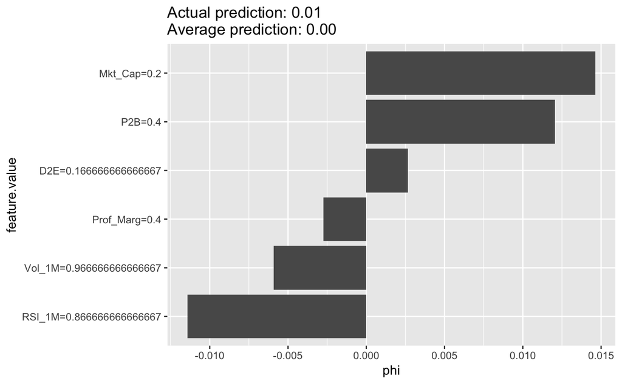

```r
if(!require(iml)){install.packages("iml")}
library(iml)                       # Interpretable ML package
predictor <- Predictor$new(fit,    # This wraps the model & data
                          data = train_features,
                          y = train_sample$F_Return)
shapley <- Shapley$new(predictor, x.interest = train_features[1,]) # Compute the Shapley values
shapley$plot()                                                     # Plot the values!
```

# 4 Deflated Sharpe ratios

## 4.1 Theory

This section is based on Bailey and Lopez de Prado (2014). The problem we address is that of **backtest overfitting**. When a manager or analyst tests a strategy on past data, a major risk is that a false positive emerges: the strategy will seem profitable in the test, but will lose money in live trading. In practice the analyst will test many strategies and only select a few: those that performed best in-sample. In order to correct for in-sample results that seem too optimistic, it is customary to **shrink Sharpe ratios** by some factor, usually close to 0.5.

Bailey and Lopez de Prado (2014) propose an approach to evaluate the statistical significance of Sharpe ratios when $M$ strategies have been tested. Usually, the one with **maximum SR** is favoured. But is it a statistically sound choice?

The following test procedure will assess its relevance
$$t = \phi\left(\frac{(SR-SR^*)\sqrt{T-1})}{\sqrt{1-\gamma_3SR+\frac{\gamma_4-1}{4}SR^2}} \right),$$

where $\gamma_3$ and $\gamma_4$ are the **skewness** and **kurtosis** of the returns of the strategy and $SR^*$ is the **theoretical average value** of the maximum SR over $M$ trials:

$$SR^*=\mathbb{E}[SR_m]+\sqrt{\mathbb{V}[SR_m]}\left((1-\gamma)\phi^{-1}\left(1-\frac{1}{N}\right)+\gamma \phi^{-1}\left(1-\frac{1}{Ne}\right) \right),$$

where $\phi$ is the cdf of the standard Gaussian law and $\gamma$ is the Euler-Mascheroni constant. The index $m$ refers to the strategy trials. If $t$ defined above is below a certain threshold (e.g., 0.95), then the $SR$ cannot be deemed significant.

## 4.2 Practice

We now illustrate this result.

Our (very bad) research strategy is to test factor strategies based on thresholds. We pick one **feature** (e.g., **Mkt_Cap**) and test a policy that invests uniformly (EW portfolios) only in the stocks that are the most tilted towards one direction, i.e., above or below a particular threshold. In this (**Mkt_Cap**) case, invest in small firms, or large firms. And we then repeat the operation over all features. This generates a large array of strategies. Each strategy has three components:

- the choice of the **feature**
- the **decision threshold** (beyond or below which level do we invest in the stock)
- the **decision direction** (do we invest when the feature is above or below the threshold)

We create the corresponding function below.

```r
strat <- function(data, feature, thresh, direction){
    data_tmp <- select(data, feature, Date, F_Return)      # Data
    colnames(data_tmp)[1] <- "feature"                     # Colname
    data_tmp %>%
        mutate(decision = direction * feature > direction * thresh) %>% # Investment decision
        group_by(Date) %>%                                          # Date-by-date  analysis
        mutate(nb = sum(decision),                                  # Nb assets in portfolio
               w = decision / nb,                                   # Weights of assets
               return = w * F_Return) %>%                           # Asset contribution
        summarise(p_return = sum(return)) %>%                       # Portfolio return
        summarise(avg = mean(p_return), sd = sd(p_return), SR = avg/sd) %>% # Perf. metrics
        return()
}
```

We then test the function on two possible strategies (i.e, choice of triplet).

```r
strat(data_f, "Mkt_Cap", 0.5, 1)   # Large cap
```

| avg | sd | SR |
| --- | --- | --- |
| 0.002013734 | 0.04622556 | 0.04356322 |

```r
strat(data_f, "Mkt_Cap", 0.5, -1)  # Small cap
```

| avg | sd | SR |
| --- | --- | --- |
| 0.01116811 | 0.05063737 | 0.2205508 |

The first line tests a strategy that invests when **Mkt_Cap** is larger than 0.5 (**note**: we work with **data_f**, hence the feature values all lie in [0,1]). The second does the opposite (i.e., invests in small firms) and is much more profitable.

We then test a large panel of configuration via a **grid approach**: we use **brute-force** data-mining which is not often the best idea.

```r
feature <- c("Mkt_Cap", "P2B", "Vol_1M", "RSI_1M", "D2E", "Prof_Marg")  # Features
thresh <- seq(0.2,0.8, by = 0.1)                                        # Threshold values values
direction <- c(1,-1)                                                    # Decision direction
pars <- expand.grid(feature, thresh, direction)                         # The grid
feature <- pars[,1] %>% as.character()                                  # re-features
thresh <- pars[,2]                                                      # re-thresholds
direction <- pars[,3]                                                   # re-directions
```

Finally, we run the loop inside the **pmap**() wrapper.

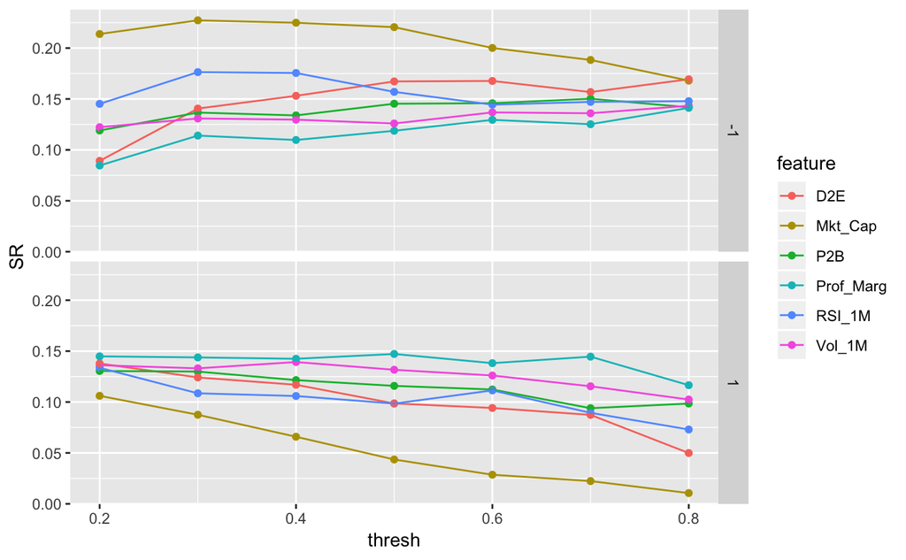

```r
grd <- pmap(list(feature, thresh, direction),      # Parameters for the grid search
            strat,                                 # Function on which to apply the grid search
            data = data_f                          # Data source/input
) %>%
    unlist() %>%
    matrix(ncol = 3, byrow = T)
grd <- data.frame(feature, thresh, direction, grd)              # Gather & reformat results
colnames(grd)[4:6] <- c("mean", "sd", "SR")                     # Change colnames
grd <- grd %>% mutate_at(vars(direction), as.factor)            # Change type: factor (for plot)
grd %>% ggplot(aes(x = thresh, y = SR, color = feature)) +      # Plot!
    geom_point() + geom_line() + facet_grid(direction~.)
```

The biggest effect of direction is observed for **Mkt_Cap**. As usual, this is the most decisive variable in our sample.

**Note**: these are SR at the monthly frequency. There is a time-scale effect with the SR: the numerator is proportional to time while the denominator is proportional to its square root. Hence a simple proxy for annualised SR is the monthly SR times $\sqrt{12}$.

The **best strategy** in the above set is to invest in firms that are below the 0.3 quantile of market capitalisation. This would be our choice. Is it relevant? Let’s find out using the deflated SR test.

```r
DSR <- function(SR, Tt, M, g3, g4, SR_m, SR_v){ # First, we build the function
    gamma <- -digamma(1)                        # Euler-Mascheroni constant
    SR_star <- SR_m + sqrt(SR_v)*((1-gamma)*qnorm(1-1/M) + gamma*qnorm(1-1/M/exp(1))) # Avg. Max SR
    num <- (SR-SR_star) * sqrt(Tt-1)            # Numerator
    den <- sqrt(1 - g3*SR + (g4-1)/4*SR^2)      # Denominator
    return(pnorm(num/den))
}
# Next, the parameters:
M <- nrow(pars)             # Number of strategies we tested
SR <- max(grd$SR)           # The SR we want to test
SR_m <- mean(grd$SR)        # Average SR across all strategies
SR_v <- var(grd$SR)         # Std dev of SR
# Below, we compute the returns of the strategy by recycling the code of the strat() function
data_tmp <- select(data_f, "Mkt_Cap", Date, F_Return) # Mkt_Cap is the retained feature
colnames(data_tmp)[1] <- "feature"
returns <-  data_tmp %>%
        mutate(decision = feature < 0.3) %>% # Investment decision: 0.3 is the best threshold
        group_by(Date) %>%                   # Date-by-date computations
        mutate(nb = sum(decision),           # Nb assets in portfolio
               w = decision / nb,            # Portfolio weights
               return = w * F_Return) %>%    # Asset contribution to return
        summarise(p_return = sum(return))    # Portfolio return
g3 <- skewness(returns$p_return)        # Function from the e1071 package
g4 <- kurtosis(returns$p_return) + 3    # Function from the e1071 package
Tt <- nrow(returns)                     # Number of dates
DSR(SR, Tt, M, g3, g4, SR_m, SR_v)      # The sought value!
```

```
[1] 0.4986262
```

This value is very far from the **0.95 confidence threshold**. The SR of our best strategy is **not statistically significant** because its location compared to the distribution of all SR is not enough to the right.

# 5 Exercises

## 5.1 Optimised forecasts

We have seen that the correlation between errors are too high in our base case ensemble model (with 3 learners). Try to build a similar aggregation model but with the predictors being the variations of the raw predictors ($\Delta X_t=X_t-X_{t-1}$). Use the **mutate**() or **mutate_at**() and **lag**() functions to create the variations.

## 5.2 SVM portfolios

Create a portfolio strategy based on **SVM forecasts**. Choose your variables wisely.